# Assignment1_PimaDataset

Assignment (Python for Machine Learning) Pima dataset

```python
import numpy as np
import pandas as pd
import matplotlib.pyplot as plt
import seaborn as sns
```

Import file into dataframe

```python
pimaDF = pd.read_csv('Downloads\diabetes.csv')
```

```python
pimaDF.head()
```

|  | Pregnancies | Glucose | BloodPressure | SkinThickness | Insulin | BMI | DiabetesPedigreeFunction | Age | Outcome |
| --- | --- | --- | --- | --- | --- | --- | --- | --- | --- |
| 0 | 6 | 148 | 72 | 35 | 0 | 33.6 | 0.627 | 50 | 1 |
| 1 | 1 | 85 | 66 | 29 | 0 | 26.6 | 0.351 | 31 | 0 |
| 2 | 8 | 183 | 64 | 0 | 0 | 23.3 | 0.672 | 32 | 1 |
| 3 | 1 | 89 | 66 | 23 | 94 | 28.1 | 0.167 | 21 | 0 |
| 4 | 0 | 137 | 40 | 35 | 168 | 43.1 | 2.288 | 33 | 1 |

```python
pimaDF.info()
```

```
<class 'pandas.core.frame.DataFrame'>
RangeIndex: 768 entries, 0 to 767
Data columns (total 9 columns):
Pregnancies                 768 non-null int64
Glucose                     768 non-null int64
BloodPressure               768 non-null int64
SkinThickness               768 non-null int64
Insulin                     768 non-null int64
BMI                         768 non-null float64
DiabetesPedigreeFunction    768 non-null float64
Age                         768 non-null int64
Outcome                     768 non-null int64
dtypes: float64(2), int64(7)
memory usage: 54.1 KB
```

```python
pimaDF.describe()
```

|  | Pregnancies | Glucose | BloodPressure | SkinThickness | Insulin | BMI | DiabetesPedigreeFunction | Age | Outcome |
| --- | --- | --- | --- | --- | --- | --- | --- | --- | --- |
| count | 768.000000 | 768.000000 | 768.000000 | 768.000000 | 768.000000 | 768.000000 | 768.000000 | 768.000000 | 768.000000 |
| mean | 3.845052 | 120.894531 | 69.105469 | 20.536458 | 79.799479 | 31.992578 | 0.471876 | 33.240885 | 0.348958 |
| std | 3.369578 | 31.972618 | 19.355807 | 15.952218 | 115.244002 | 7.884160 | 0.331329 | 11.760232 | 0.476951 |
| min | 0.000000 | 0.000000 | 0.000000 | 0.000000 | 0.000000 | 0.000000 | 0.078000 | 21.000000 | 0.000000 |
| 25% | 1.000000 | 99.000000 | 62.000000 | 0.000000 | 0.000000 | 27.300000 | 0.243750 | 24.000000 | 0.000000 |
| 50% | 3.000000 | 117.000000 | 72.000000 | 23.000000 | 30.500000 | 32.000000 | 0.372500 | 29.000000 | 0.000000 |
| 75% | 6.000000 | 140.250000 | 80.000000 | 32.000000 | 127.250000 | 36.600000 | 0.626250 | 41.000000 | 1.000000 |
| max | 17.000000 | 199.000000 | 122.000000 | 99.000000 | 846.000000 | 67.100000 | 2.420000 | 81.000000 | 1.000000 |

Identifying the missing/wrong observations in the data. With domain knowledge we understand that below columns cannot be zero:

1. Glucose
2. BloodPressure
3. SkinThickness
4. Insulin
5. BMI

```python
print((pimaDF[['Glucose','BloodPressure','SkinThickness','Insulin','BMI']] == 0).sum())
```

```
Glucose            5
BloodPressure     35
SkinThickness    227
Insulin          374
BMI               11
dtype: int64
```

```python
pimaDF_copy = pimaDF.copy()
```

Marking this missing information with NaN

```python
pimaDF_copy[['Glucose','BloodPressure','SkinThickness','Insulin','BMI']] = pimaDF_copy[['Glucose','BloodPressure','SkinThickness','Insulin','BMI']].replace(0,np.NaN)
```

```python
pimaDF_copy.isnull().sum()
```

```
Pregnancies                   0
Glucose                       5
BloodPressure                35
SkinThickness               227
Insulin                     374
BMI                          11
DiabetesPedigreeFunction      0
Age                           0
Outcome                       0
dtype: int64
```

```python
pimaDF_copy.head(10)
```

[output not shown]

```python
#Using median as it not affected by outliers
pimaDF_copy.fillna(pimaDF_copy.median(),inplace=True)
pimaDF_copy.head()
```

|  | Pregnancies | Glucose | BloodPressure | SkinThickness | Insulin | BMI | DiabetesPedigreeFunction | Age | Outcome |
| --- | --- | --- | --- | --- | --- | --- | --- | --- | --- |
| 0 | 6 | 148.0 | 72.0 | 35.0 | 125.0 | 33.6 | 0.627 | 50 | 1 |
| 1 | 1 | 85.0 | 66.0 | 29.0 | 125.0 | 26.6 | 0.351 | 31 | 0 |
| 2 | 8 | 183.0 | 64.0 | 29.0 | 125.0 | 23.3 | 0.672 | 32 | 1 |
| 3 | 1 | 89.0 | 66.0 | 23.0 | 94.0 | 28.1 | 0.167 | 21 | 0 |
| 4 | 0 | 137.0 | 40.0 | 35.0 | 168.0 | 43.1 | 2.288 | 33 | 1 |

```
Outcome
0    [[AxesSubplot(0.125,0.670278;0.215278x0.209722...
1    [[AxesSubplot(0.125,0.670278;0.215278x0.209722...
dtype: object
```

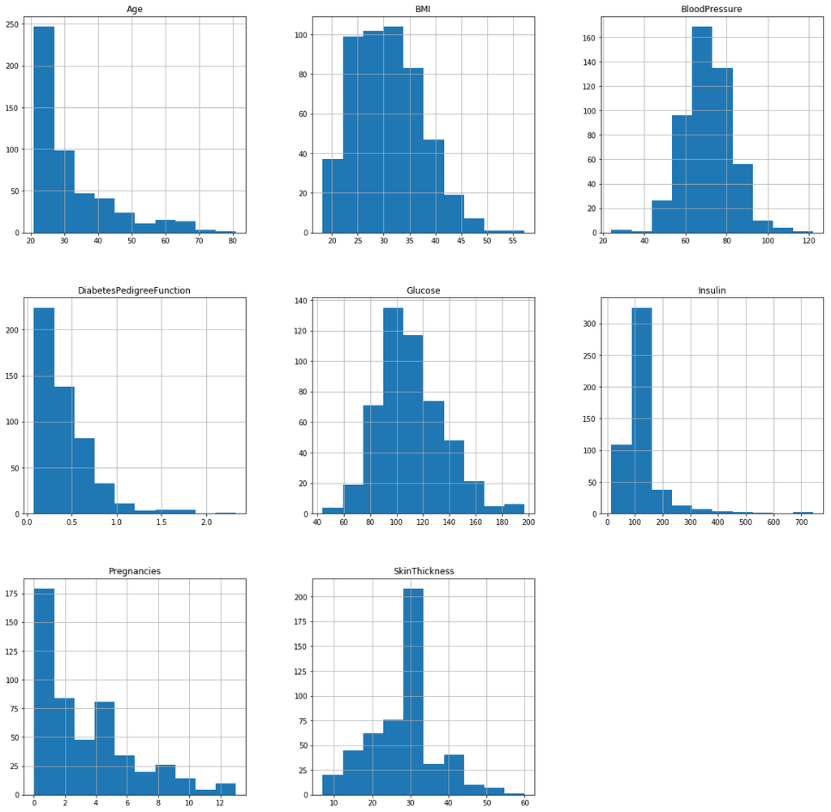

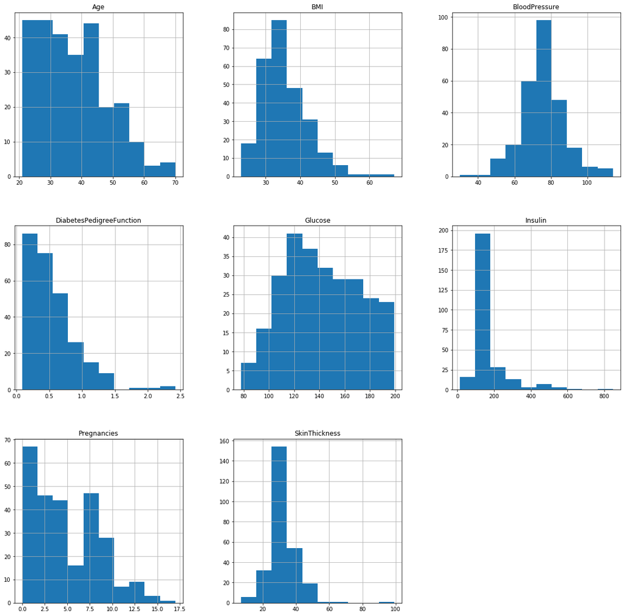

```python
pimaDF_copy.groupby('Outcome').hist(figsize=(20,20))
```

From observing the histograms attributes Glucose, BMI, Blood Pressure and skin thickness seems to be normally distributed. Pregnancies, Insulin, Age and DiabetesPedegreeFunction seems to be exponentially distributed.

```
array([[<matplotlib.axes._subplots.AxesSubplot object at 0x000002EC6E38B828>,
      dtype=object)
```

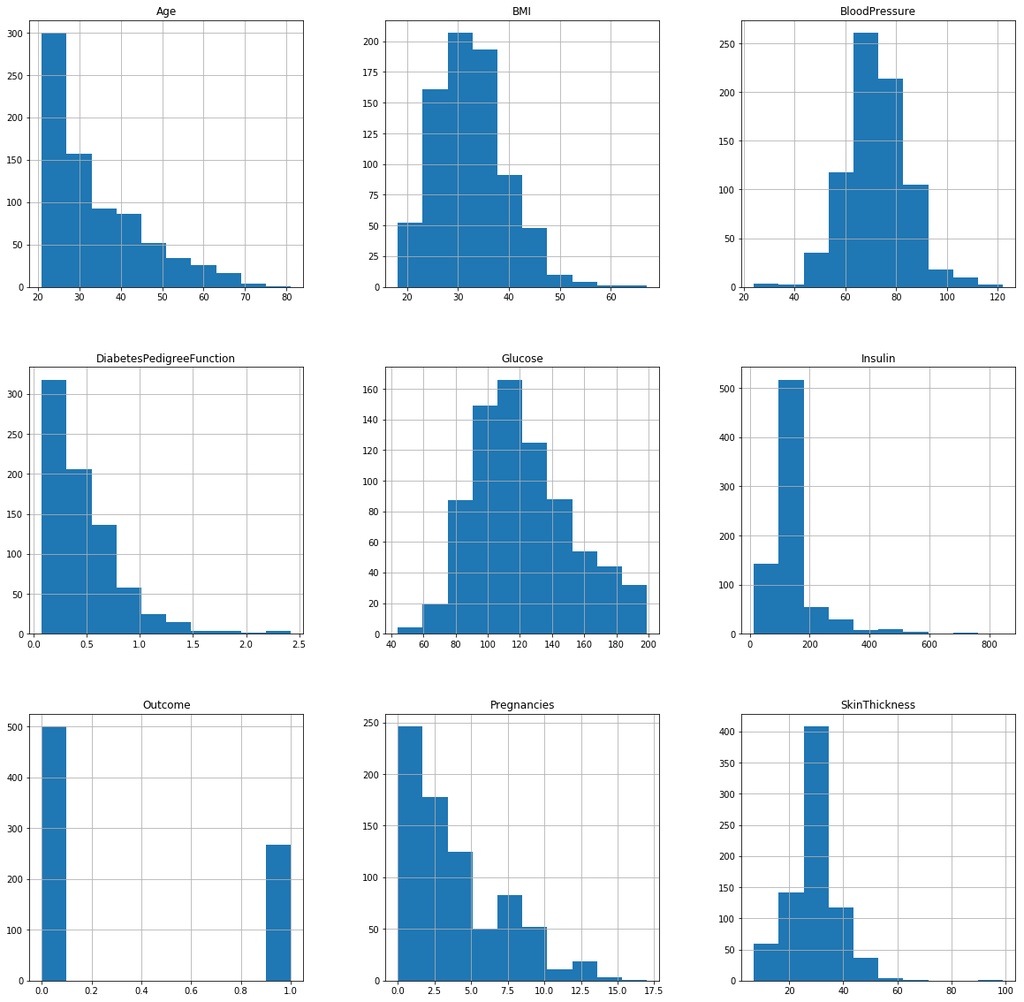

```python
pimaDF_copy.hist(figsize=(20,20))
```

```python
corr = pimaDF_copy.corr()
corr
```

|  | Pregnancies | Glucose | BloodPressure | SkinThickness | Insulin | BMI | DiabetesPedigreeFunction | Age | Outcome |
| --- | --- | --- | --- | --- | --- | --- | --- | --- | --- |
| Pregnancies | 1.000000 | 0.128213 | 0.208615 | 0.081770 | 0.025047 | 0.021559 | -0.033523 | 0.544341 | 0.221898 |
| Glucose | 0.128213 | 1.000000 | 0.218937 | 0.192615 | 0.419451 | 0.231049 | 0.137327 | 0.266909 | 0.492782 |
| BloodPressure | 0.208615 | 0.218937 | 1.000000 | 0.191892 | 0.045363 | 0.281257 | -0.002378 | 0.324915 | 0.165723 |
| SkinThickness | 0.081770 | 0.192615 | 0.191892 | 1.000000 | 0.155610 | 0.543205 | 0.102188 | 0.126107 | 0.214873 |
| Insulin | 0.025047 | 0.419451 | 0.045363 | 0.155610 | 1.000000 | 0.180241 | 0.126503 | 0.097101 | 0.203790 |
| BMI | 0.021559 | 0.231049 | 0.281257 | 0.543205 | 0.180241 | 1.000000 | 0.153438 | 0.025597 | 0.312038 |
| DiabetesPedigreeFunction | -0.033523 | 0.137327 | -0.002378 | 0.102188 | 0.126503 | 0.153438 | 1.000000 | 0.033561 | 0.173844 |
| Age | 0.544341 | 0.266909 | 0.324915 | 0.126107 | 0.097101 | 0.025597 | 0.033561 | 1.000000 | 0.238356 |
| Outcome | 0.221898 | 0.492782 | 0.165723 | 0.214873 | 0.203790 | 0.312038 | 0.173844 | 0.238356 | 1.000000 |

From the correlation matrix it seems like the outcome variable is dependant/having good(moderate) co-relation with independant variables Glucose(0.49), BMI(0.31), Age(0.24) and Pregnancies(0.22)

Also there seems to be correlation between other features like between Age and Pregnancies(0.54), between Skin Thickness and BMI(0u.54), between Glucose and Insulin(0.42)

DiabetesPedigreeFunction is negatively correlated with BloodPressure(-0.002378) and Pregnancies(-0.033523).

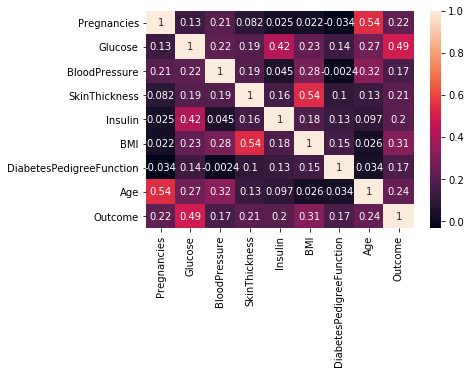

```python
sns.heatmap(corr, annot=True)
```

```
<BarContainer object of 768 artists>
```

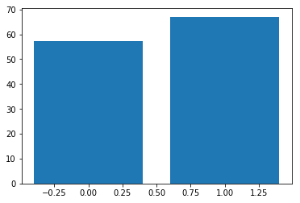

```python
plt.bar(pimaDF_copy.Outcome, pimaDF_copy.BMI)
```

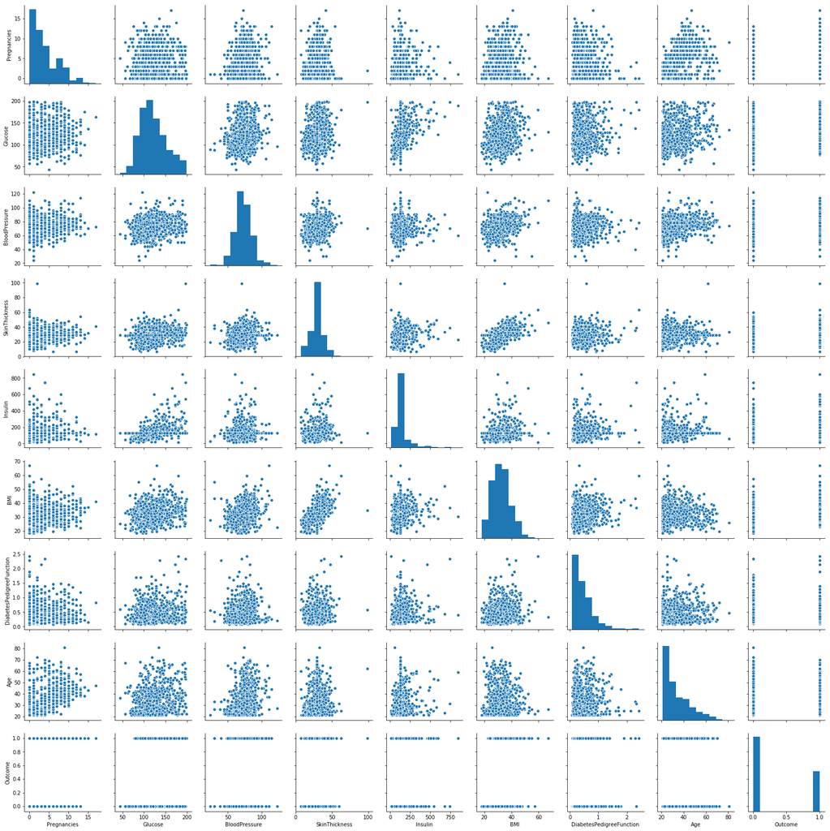

```python
sns.pairplot(pimaDF_copy)
```

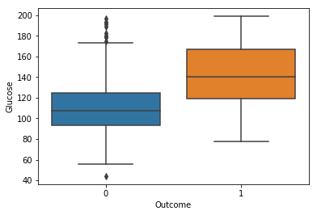

```python
sns.boxplot(x="Outcome", y="Glucose", data=pimaDF_copy)
```

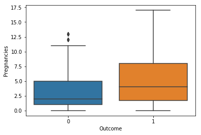

```python
sns.boxplot(x="Outcome", y="Pregnancies", data=pimaDF_copy)
```

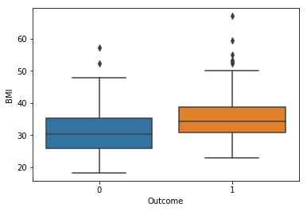

```python
sns.boxplot(x="Outcome", y="BMI", data=pimaDF_copy)
#From Boxplot seems like when outcome is 0 i.e. negative test for diabetes have lower BMI compared
#to those who tested positive for diabetes
```

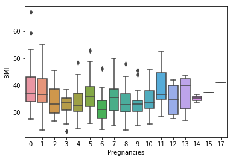

```python
sns.boxplot(x="Pregnancies", y="BMI", data=pimaDF_copy[pimaDF_copy.Outcome==1])
```

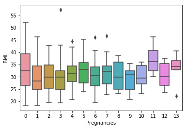

```python
sns.boxplot(x="Pregnancies", y="BMI", data=pimaDF_copy[pimaDF_copy.Outcome==0])
```

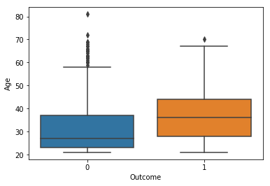

```python
sns.boxplot(x="Outcome", y="Age", data=pimaDF_copy)
#As there are many outliers for negative diabetes test data, we cannot conclude if Age and diabetes
#are really dependant
```

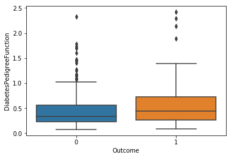

```python
sns.boxplot(x="Outcome", y="DiabetesPedigreeFunction", data=pimaDF_copy)
```

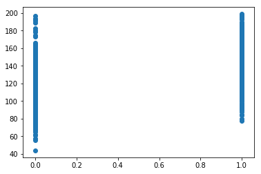

```python
plt.scatter(pimaDF_copy.Outcome,pimaDF_copy.Glucose)
```

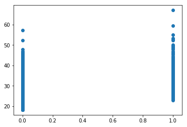

```python
plt.scatter(pimaDF_copy.Outcome,pimaDF_copy.BMI)
```

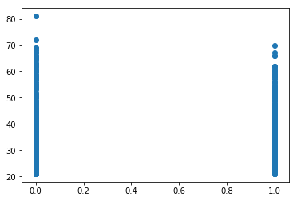

```python
plt.scatter(pimaDF_copy.Outcome,pimaDF_copy.Age)
```

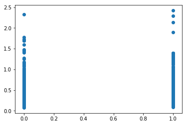

```python
plt.scatter(pimaDF_copy.Outcome,pimaDF_copy.DiabetesPedigreeFunction)
```

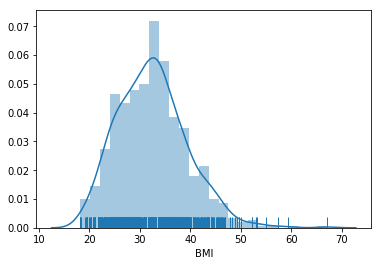

```python
sns.distplot(pimaDF_copy['BMI'],rug=True)
```

```python
pd.crosstab(pimaDF_copy['Outcome'] , pimaDF_copy['Pregnancies'])
```

| Pregnancies Outcome | 0 | 1 | 2 | 3 | 4 | 5 | 6 | 7 | 8 | 9 | 10 | 11 | 12 | 13 | 14 | 15 | 17 |
| --- | --- | --- | --- | --- | --- | --- | --- | --- | --- | --- | --- | --- | --- | --- | --- | --- | --- |
| 0 | 73 | 106 | 84 | 48 | 45 | 36 | 34 | 20 | 16 | 10 | 14 | 4 | 5 | 5 | 0 | 0 | 0 |
| 1 | 38 | 29 | 19 | 27 | 23 | 21 | 16 | 25 | 22 | 18 | 10 | 7 | 4 | 5 | 2 | 1 | 1 |

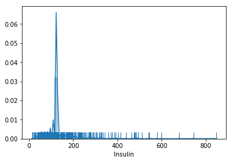

```python
sns.distplot(pimaDF_copy['Insulin'],rug=True)
```

[output not shown]